# RF_regression

[figure not shown]

## [Prof. Pedram Jahangiry](https://huntsman.usu.edu/directory/jahangiry-pedram)

[GitHub account](https://github.com/PJalgotrader)

[YouTube Channel](https://www.youtube.com/channel/UCNDElcuuyX-2pSatVBDpJJQ/playlists)

```python
import numpy as np
import pandas as pd
import matplotlib.pyplot as plt
import seaborn as sns
sns.set()  #if you want to use seaborn themes with matplotlib functions
import statsmodels.api as sm

import warnings
warnings.filterwarnings('ignore')
```

```python
df=pd.read_csv('Logan_housing.csv')
```

```python
df.head(10)
```

|  | Sold Price | DOM | Garage Capacity | HOA Fee | Irregular Shape | Quadrant | School District | Sold Terms | Total Bedrooms | Total Bathrooms | Total Square Feet | Year Built | Zip | year_sold | month_sold | built_after_2000 |
| --- | --- | --- | --- | --- | --- | --- | --- | --- | --- | --- | --- | --- | --- | --- | --- | --- |
| 0 | 176000 | 5 | 2 | 0 | No | NW | Cache | FHA | 3 | 1 | 1031 | 1974 | 84335 | 2018 | 9 | 0 |
| 1 | 225000 | 6 | 2 | 0 | No | NW | Cache | Conventional | 4 | 2 | 2091 | 1995 | 84335 | 2018 | 7 | 0 |
| 2 | 274900 | 14 | 2 | 0 | No | NW | Cache | Conventional | 3 | 1 | 2016 | 1980 | 84335 | 2018 | 11 | 0 |
| 3 | 175000 | 16 | 1 | 0 | No | NW | Cache | USDA Rural Development | 4 | 1 | 1920 | 1978 | 84335 | 2018 | 6 | 0 |
| 4 | 179000 | 29 | 0 | 0 | No | NW | Cache | Cash | 4 | 2 | 1329 | 1976 | 84335 | 2018 | 9 | 0 |
| 5 | 299900 | 130 | 2 | 0 | No | NW | Cache | Conventional | 6 | 3 | 2765 | 1926 | 84335 | 2018 | 9 | 0 |
| 6 | 424000 | 463 | 6 | 0 | No | NW | Cache | Conventional | 4 | 4 | 5000 | 1933 | 84335 | 2019 | 12 | 0 |
| 7 | 775000 | 37 | 2 | 0 | No | SE | Cache | Conventional | 5 | 4 | 5180 | 1999 | 84328 | 2020 | 8 | 0 |
| 8 | 611000 | 38 | 2 | 0 | No | SE | Cache | VA | 5 | 3 | 4308 | 2015 | 84328 | 2020 | 11 | 1 |
| 9 | 1131310 | 115 | 2 | 0 | Yes | SE | Cache | Cash | 4 | 2 | 2116 | 1985 | 84328 | 2020 | 4 | 0 |

```python
df.info()
```

```
<class 'pandas.core.frame.DataFrame'>
RangeIndex: 4110 entries, 0 to 4109
Data columns (total 16 columns):
Sold Price           4110 non-null int64
DOM                  4110 non-null int64
Garage Capacity      4110 non-null int64
HOA Fee              4110 non-null int64
Irregular Shape      4110 non-null object
Quadrant             4110 non-null object
School District      4110 non-null object
Sold Terms           4110 non-null object
Total Bedrooms       4110 non-null int64
Total Bathrooms      4110 non-null int64
Total Square Feet    4110 non-null int64
Year Built           4110 non-null int64
Zip                  4110 non-null int64
year_sold            4110 non-null int64
month_sold           4110 non-null int64
built_after_2000     4110 non-null int64
dtypes: int64(12), object(4)
memory usage: 513.8+ KB
```

First we need to see if any data is missing

```python
df.isnull().sum()/len(df)
```

```
Sold Price           0.0
DOM                  0.0
Garage Capacity      0.0
HOA Fee              0.0
Irregular Shape      0.0
Quadrant             0.0
School District      0.0
Sold Terms           0.0
Total Bedrooms       0.0
Total Bathrooms      0.0
Total Square Feet    0.0
Year Built           0.0
Zip                  0.0
year_sold            0.0
month_sold           0.0
built_after_2000     0.0
dtype: float64
```

Looks good! Now let's see if there are any duplicates!

```python
sum(df.duplicated())
```

```
2
```

```python
# dropping the duplicates:
df.drop_duplicates(inplace=True)
```

```python
df.nunique()
```

```
Sold Price           1217
DOM                   248
Garage Capacity        14
HOA Fee                96
Irregular Shape         2
Quadrant                4
School District         2
Sold Terms              6
Total Bedrooms          9
Total Bathrooms         7
Total Square Feet    2009
Year Built            136
Zip                    16
year_sold               3
month_sold             12
built_after_2000        2
dtype: int64
```

### Encode ordinal categorical features as an integer array.

In random forest we don't need to transfer the categorical variables into dummy variables (using one-hot-encoding). However, the algorithm is not able to handel ordinal data. We should transform ordinal categorical variables into quantitative variables.

```python
df.head()
```

|  | Sold Price | DOM | Garage Capacity | HOA Fee | Irregular Shape | Quadrant | School District | Sold Terms | Total Bedrooms | Total Bathrooms | Total Square Feet | Year Built | Zip | year_sold | month_sold | built_after_2000 |
| --- | --- | --- | --- | --- | --- | --- | --- | --- | --- | --- | --- | --- | --- | --- | --- | --- |
| 0 | 176000 | 5 | 2 | 0 | No | NW | Cache | FHA | 3 | 1 | 1031 | 1974 | 84335 | 2018 | 9 | 0 |
| 1 | 225000 | 6 | 2 | 0 | No | NW | Cache | Conventional | 4 | 2 | 2091 | 1995 | 84335 | 2018 | 7 | 0 |
| 2 | 274900 | 14 | 2 | 0 | No | NW | Cache | Conventional | 3 | 1 | 2016 | 1980 | 84335 | 2018 | 11 | 0 |
| 3 | 175000 | 16 | 1 | 0 | No | NW | Cache | USDA Rural Development | 4 | 1 | 1920 | 1978 | 84335 | 2018 | 6 | 0 |
| 4 | 179000 | 29 | 0 | 0 | No | NW | Cache | Cash | 4 | 2 | 1329 | 1976 | 84335 | 2018 | 9 | 0 |

```python
ordinal_categorical = ['Irregular Shape', 'Quadrant', 'School District', 'Sold Terms', 'Zip']
```

```python
from sklearn.preprocessing import OrdinalEncoder
```

```python
enc = OrdinalEncoder()
```

```python
df[ordinal_categorical]= enc.fit_transform(df[ordinal_categorical])
```

```python
df.head()
```

|  | Sold Price | DOM | Garage Capacity | HOA Fee | Irregular Shape | Quadrant | School District | Sold Terms | Total Bedrooms | Total Bathrooms | Total Square Feet | Year Built | Zip | year_sold | month_sold | built_after_2000 |
| --- | --- | --- | --- | --- | --- | --- | --- | --- | --- | --- | --- | --- | --- | --- | --- | --- |
| 0 | 176000 | 5 | 2 | 0 | 0.0 | 1.0 | 0.0 | 2.0 | 3 | 1 | 1031 | 1974 | 12.0 | 2018 | 9 | 0 |
| 1 | 225000 | 6 | 2 | 0 | 0.0 | 1.0 | 0.0 | 1.0 | 4 | 2 | 2091 | 1995 | 12.0 | 2018 | 7 | 0 |
| 2 | 274900 | 14 | 2 | 0 | 0.0 | 1.0 | 0.0 | 1.0 | 3 | 1 | 2016 | 1980 | 12.0 | 2018 | 11 | 0 |
| 3 | 175000 | 16 | 1 | 0 | 0.0 | 1.0 | 0.0 | 4.0 | 4 | 1 | 1920 | 1978 | 12.0 | 2018 | 6 | 0 |
| 4 | 179000 | 29 | 0 | 0 | 0.0 | 1.0 | 0.0 | 0.0 | 4 | 2 | 1329 | 1976 | 12.0 | 2018 | 9 | 0 |

```python
enc.categories_
```

```
[array(['No', 'Yes'], dtype=object),
 array(['NE', 'NW', 'SE', 'SW'], dtype=object),
 array(['Cache', 'Logan'], dtype=object),
 array(['Cash', 'Conventional', 'FHA', 'Other', 'USDA Rural Development',
        'VA'], dtype=object),
 array([84305, 84308, 84318, 84319, 84320, 84321, 84325, 84326, 84327,
        84328, 84332, 84333, 84335, 84338, 84339, 84341], dtype=int64)]
```

```python
df.info()
```

```
<class 'pandas.core.frame.DataFrame'>
Int64Index: 4108 entries, 0 to 4109
Data columns (total 16 columns):
Sold Price           4108 non-null int64
DOM                  4108 non-null int64
Garage Capacity      4108 non-null int64
HOA Fee              4108 non-null int64
Irregular Shape      4108 non-null float64
Quadrant             4108 non-null float64
School District      4108 non-null float64
Sold Terms           4108 non-null float64
Total Bedrooms       4108 non-null int64
Total Bathrooms      4108 non-null int64
Total Square Feet    4108 non-null int64
Year Built           4108 non-null int64
Zip                  4108 non-null float64
year_sold            4108 non-null int64
month_sold           4108 non-null int64
built_after_2000     4108 non-null int64
dtypes: float64(5), int64(11)
memory usage: 545.6 KB
```

```python
df.describe().T
```

|  | count | mean | std | min | 25% | 50% | 75% | max |
| --- | --- | --- | --- | --- | --- | --- | --- | --- |
| Sold Price | 4108.0 | 282140.958861 | 117889.761244 | 13000.0 | 214000.0 | 260000.0 | 324900.00 | 1900000.0 |
| DOM | 4108.0 | 40.541383 | 51.578459 | 1.0 | 6.0 | 23.0 | 56.00 | 712.0 |
| Garage Capacity | 4108.0 | 1.825949 | 1.094350 | 0.0 | 1.0 | 2.0 | 2.00 | 20.0 |
| HOA Fee | 4108.0 | 36.149708 | 69.567184 | 0.0 | 0.0 | 0.0 | 65.00 | 1050.0 |
| Irregular Shape | 4108.0 | 0.089825 | 0.285965 | 0.0 | 0.0 | 0.0 | 0.00 | 1.0 |
| Quadrant | 4108.0 | 1.511198 | 1.166500 | 0.0 | 0.0 | 2.0 | 3.00 | 3.0 |
| School District | 4108.0 | 0.334713 | 0.471947 | 0.0 | 0.0 | 0.0 | 1.00 | 1.0 |
| Sold Terms | 4108.0 | 1.497809 | 1.172589 | 0.0 | 1.0 | 1.0 | 2.00 | 5.0 |
| Total Bedrooms | 4108.0 | 3.821568 | 1.182846 | 1.0 | 3.0 | 4.0 | 5.00 | 9.0 |
| Total Bathrooms | 4108.0 | 2.577167 | 0.851321 | 1.0 | 2.0 | 3.0 | 3.00 | 7.0 |
| Total Square Feet | 4108.0 | 2370.712756 | 1049.821233 | 520.0 | 1583.0 | 2141.0 | 2942.25 | 10890.0 |
| Year Built | 4108.0 | 1989.272395 | 31.285221 | 1879.0 | 1976.0 | 2001.0 | 2012.00 | 2020.0 |
| Zip | 4108.0 | 7.953992 | 4.473668 | 0.0 | 5.0 | 5.0 | 12.00 | 15.0 |
| year_sold | 4108.0 | 2019.009981 | 0.816585 | 2018.0 | 2018.0 | 2019.0 | 2020.00 | 2020.0 |
| month_sold | 4108.0 | 6.678676 | 3.032968 | 1.0 | 4.0 | 7.0 | 9.00 | 12.0 |
| built_after_2000 | 4108.0 | 0.517283 | 0.499762 | 0.0 | 0.0 | 1.0 | 1.00 | 1.0 |

```python
df.drop('built_after_2000', axis=1, inplace=True) #why?
```

```python
df.shape
```

```
(4108, 15)
```

Remember, with other machine learning models, we ended up with **58 features** using the same data set because we had to transform categorical variables into dummies. But with RF, there is only **14 features** to work with.

### Scaling features

In random forest, we don't need to scale the features!!

### Defining the variables and splitting the data

```python
rand_state = 1000
```

```python
y = df['Sold Price']
X = df.drop('Sold Price', axis=1) # becareful inplace= False

from sklearn.model_selection import train_test_split
X_train, X_test, y_train, y_test = train_test_split(X, y, test_size=0.3, random_state=rand_state)
```

### Random Forest Regression

```python
from sklearn.ensemble import RandomForestRegressor
```

```python
# Fitting RF regression to the Training set
RF_regression = RandomForestRegressor(random_state=rand_state)
RF_regression.fit(X_train, y_train)
```

```
RandomForestRegressor(random_state=1000)
```

```python
# Predicting the Test set results
y_hat = RF_regression.predict(X_test)
```

```python
predictions = pd.DataFrame({ 'y_test':y_test,'y_hat':y_hat})
predictions.head()
```

|  | y_test | y_hat |
| --- | --- | --- |
| 4086 | 234500 | 262465.62 |
| 2938 | 200685 | 208367.15 |
| 175 | 345500 | 383041.50 |
| 1940 | 230000 | 229644.23 |
| 1763 | 299000 | 379370.31 |

### Evaluating the model on test dataset¶

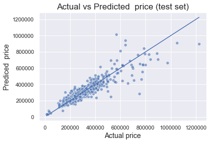

```python
sns.scatterplot(x=y_test, y=y_hat, alpha=0.6)
sns.lineplot(y_test, y_test)

plt.xlabel('Actual price', fontsize=14)
plt.ylabel('Prediced  price', fontsize=14)
plt.title('Actual vs Predicted  price (test set)', fontsize=17)
plt.show()
```

```python
np.round(RF_regression.score(X_test, y_test),4)
```

```
0.8379
```

Reminder: The $R^2$ using an SVM model was around 73%. Vanilla base RF is outperforming SVM.

```python
MSE_test = round(np.mean(np.square(y_test - y_hat)),2)
RMSE_test = round(np.sqrt(MSE_test),2)
RMSE_test
```

```
46398.65
```

## Tuning hyperparameters:

### Gridsearch

```python
my_param_grid = {'n_estimators': [10,100,500], 'max_features':['sqrt','log2'], 'max_depth':[5,10,20]}
```

```python
from sklearn.model_selection import GridSearchCV
```

```python
GridSearchCV(estimator=RandomForestRegressor(random_state=rand_state),param_grid= my_param_grid, refit = True, verbose=2, cv=5 )
```

```
GridSearchCV(cv=5, estimator=RandomForestRegressor(random_state=1000),
             param_grid={'max_depth': [5, 10, 20],
                         'max_features': ['sqrt', 'log2'],
                         'n_estimators': [10, 100, 500]},
             verbose=2)
```

```python
grid = GridSearchCV(estimator=RandomForestRegressor(random_state=rand_state),param_grid= my_param_grid, refit = True, verbose=2, cv=5 )
# verbose just means the text output describing the process. (the greater the number the more detail you will get).
```

```python
# May take a while!
grid.fit(X_train,y_train)
```

```
Fitting 5 folds for each of 18 candidates, totalling 90 fits
[CV] END ....max_depth=5, max_features=sqrt, n_estimators=10; total time=   0.0s
[CV] END ....max_depth=5, max_features=sqrt, n_estimators=10; total time=   0.0s
[CV] END ....max_depth=5, max_features=sqrt, n_estimators=10; total time=   0.0s
[CV] END ....max_depth=5, max_features=sqrt, n_estimators=10; total time=   0.0s
[CV] END ....max_depth=5, max_features=sqrt, n_estimators=10; total time=   0.0s
[CV] END ...max_depth=5, max_features=sqrt, n_estimators=100; total time=   0.0s
[CV] END ...max_depth=5, max_features=sqrt, n_estimators=100; total time=   0.0s
[CV] END ...max_depth=5, max_features=sqrt, n_estimators=100; total time=   0.0s
[CV] END ...max_depth=5, max_features=sqrt, n_estimators=100; total time=   0.0s
[CV] END ...max_depth=5, max_features=sqrt, n_estimators=100; total time=   0.0s
[CV] END ...max_depth=5, max_features=sqrt, n_estimators=500; total time=   0.4s
[CV] END ...max_depth=5, max_features=sqrt, n_estimators=500; total time=   0.4s
[CV] END ...max_depth=5, max_features=sqrt, n_estimators=500; total time=   0.4s
[CV] END ...max_depth=5, max_features=sqrt, n_estimators=500; total time=   0.4s
[CV] END ...max_depth=5, max_features=sqrt, n_estimators=500; total time=   0.4s
[CV] END ....max_depth=5, max_features=log2, n_estimators=10; total time=   0.0s
[CV] END ....max_depth=5, max_features=log2, n_estimators=10; total time=   0.0s
[CV] END ....max_depth=5, max_features=log2, n_estimators=10; total time=   0.0s
[CV] END ....max_depth=5, max_features=log2, n_estimators=10; total time=   0.0s
[CV] END ....max_depth=5, max_features=log2, n_estimators=10; total time=   0.0s
[CV] END ...max_depth=5, max_features=log2, n_estimators=100; total time=   0.0s
[CV] END ...max_depth=5, max_features=log2, n_estimators=100; total time=   0.0s
[CV] END ...max_depth=5, max_features=log2, n_estimators=100; total time=   0.0s
[CV] END ...max_depth=5, max_features=log2, n_estimators=100; total time=   0.0s
[CV] END ...max_depth=5, max_features=log2, n_estimators=100; total time=   0.0s
[CV] END ...max_depth=5, max_features=log2, n_estimators=500; total time=   0.4s
[CV] END ...max_depth=5, max_features=log2, n_estimators=500; total time=   0.4s
[CV] END ...max_depth=5, max_features=log2, n_estimators=500; total time=   0.4s
[CV] END ...max_depth=5, max_features=log2, n_estimators=500; total time=   0.4s
[CV] END ...max_depth=5, max_features=log2, n_estimators=500; total time=   0.4s
[CV] END ...max_depth=10, max_features=sqrt, n_estimators=10; total time=   0.0s
[CV] END ...max_depth=10, max_features=sqrt, n_estimators=10; total time=   0.0s
[CV] END ...max_depth=10, max_features=sqrt, n_estimators=10; total time=   0.0s
[CV] END ...max_depth=10, max_features=sqrt, n_estimators=10; total time=   0.0s
[CV] END ...max_depth=10, max_features=sqrt, n_estimators=10; total time=   0.0s
[CV] END ..max_depth=10, max_features=sqrt, n_estimators=100; total time=   0.1s
[CV] END ..max_depth=10, max_features=sqrt, n_estimators=100; total time=   0.1s
[CV] END ..max_depth=10, max_features=sqrt, n_estimators=100; total time=   0.1s
[CV] END ..max_depth=10, max_features=sqrt, n_estimators=100; total time=   0.1s
```

[output cut: 36 more lines]

```
[CV] END ...max_depth=20, max_features=log2, n_estimators=10; total time=   0.0s
[CV] END ...max_depth=20, max_features=log2, n_estimators=10; total time=   0.0s
[CV] END ...max_depth=20, max_features=log2, n_estimators=10; total time=   0.0s
[CV] END ...max_depth=20, max_features=log2, n_estimators=10; total time=   0.0s
[CV] END ...max_depth=20, max_features=log2, n_estimators=10; total time=   0.0s
[CV] END ..max_depth=20, max_features=log2, n_estimators=100; total time=   0.2s
[CV] END ..max_depth=20, max_features=log2, n_estimators=100; total time=   0.1s
[CV] END ..max_depth=20, max_features=log2, n_estimators=100; total time=   0.2s
[CV] END ..max_depth=20, max_features=log2, n_estimators=100; total time=   0.2s
[CV] END ..max_depth=20, max_features=log2, n_estimators=100; total time=   0.2s
[CV] END ..max_depth=20, max_features=log2, n_estimators=500; total time=   1.1s
[CV] END ..max_depth=20, max_features=log2, n_estimators=500; total time=   1.1s
[CV] END ..max_depth=20, max_features=log2, n_estimators=500; total time=   1.1s
[CV] END ..max_depth=20, max_features=log2, n_estimators=500; total time=   1.1s
[CV] END ..max_depth=20, max_features=log2, n_estimators=500; total time=   1.2s
```

```
GridSearchCV(cv=5, estimator=RandomForestRegressor(random_state=1000),
             param_grid={'max_depth': [5, 10, 20],
                         'max_features': ['sqrt', 'log2'],
                         'n_estimators': [10, 100, 500]},
             verbose=2)
```

What **fit** does is a bit more involved than usual. First, it tries multiple combinations from param_grid by cross-validation to find the best parameter combination. Once it has the best combination, it retrain the model using optimal hyperparameters on the entire train set.

```python
grid.best_params_
```

```
{'max_depth': 20, 'max_features': 'sqrt', 'n_estimators': 500}
```

```python
grid.best_estimator_
```

```
RandomForestRegressor(max_depth=20, max_features='sqrt', n_estimators=500,
                      random_state=1000)
```

```python
y_hat_optimized = grid.predict(X_test)
```

```python
predictions['y_hat_optimized'] = y_hat_optimized
predictions.head()
```

|  | y_test | y_hat | y_hat_optimized |
| --- | --- | --- | --- |
| 4086 | 234500 | 262465.62 | 263663.561524 |
| 2938 | 200685 | 208367.15 | 217316.819728 |
| 175 | 345500 | 383041.50 | 389525.313035 |
| 1940 | 230000 | 229644.23 | 217183.862310 |
| 1763 | 299000 | 379370.31 | 368291.758000 |

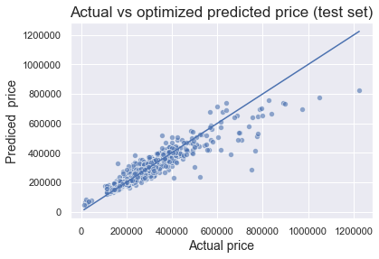

```python
sns.scatterplot(x=y_test, y=y_hat_optimized, alpha=0.6)
sns.lineplot(y_test, y_test)

plt.xlabel('Actual price', fontsize=14)
plt.ylabel('Prediced  price', fontsize=14)
plt.title('Actual vs optimized predicted price (test set)', fontsize=17)
plt.show()
```

```python
np.round(grid.score(X_test, y_test),4)
```

```
0.8486
```

```python
MSE_test_opt = round(np.mean(np.square(y_test - y_hat_optimized)),2)
RMSE_test_opt = round(np.sqrt(MSE_test_opt),2)
RMSE_test_opt
```

```
44850.32
```

compared to numbers before using gridsearch (R2= 0.8379 and RMSE= 46398), this is a slight improvement!

#### Cross validation

We will use Cross validation to estimate performance metrics in the test set.

```python
from sklearn.model_selection import cross_val_score
```

```python
NMSE = cross_val_score(estimator = RandomForestRegressor(max_depth=20, max_features='sqrt', n_estimators=500), X = X_train, y = y_train, cv = 5 , scoring="neg_mean_squared_error" )
```

```python
MSE_CV = round(np.mean(-NMSE),4)
RMSE_CV = round(np.sqrt(MSE_CV),4)
RMSE_CV
```

```
56527.2923
```

### Out-of-Bag errors!

We can show that on average, each bagged tree makes use of around 2/3 of the observations and 1/3 of them are not used to fit the model. These left out observations are called out-of-bag (OOB) observations. It turns out there is a very straightforward way to estimate the test errors using OOB observations.

```python
np.random.choice (100,size=100)
```

```
array([29, 78, 74, 58, 47, 90, 75, 49, 85, 73, 88, 97, 89, 29, 86, 46, 59,
       60, 31, 16, 25, 33, 71, 29, 22, 46, 13, 37, 19, 98, 96, 70, 97, 87,
       95, 17, 67, 72, 26, 73,  8, 30, 82, 42, 86, 10,  1,  7, 52, 15, 19,
       48, 93,  2, 22, 27, 64, 55, 72, 97, 40, 21, 83, 87, 89, 62,  7, 65,
       72, 38, 94, 50, 69,  6, 80, 53,  1, 14, 56, 48, 87, 96, 38, 70, 99,
       22, 55, 56, 53, 56, 90, 36, 91, 37, 50, 12, 77, 99, 99, 88])
```

```python
np.unique(np.random.choice (100,size=100)).size
```

```
62
```

```python
RF_oob = RandomForestRegressor(max_depth=20, max_features='sqrt', n_estimators=500, oob_score=True)
RF_oob.fit(X_train, y_train)
```

```
RandomForestRegressor(max_depth=20, max_features='sqrt', n_estimators=500,
                      oob_score=True)
```

```python
RF_oob.oob_score_
```

```
0.7798318244263656
```

### Feature Importance

```python
features = list(X_train.columns)
features
```

```
['DOM',
 'Garage Capacity',
 'HOA Fee',
 'Irregular Shape',
 'Quadrant',
 'School District',
 'Sold Terms',
 'Total Bedrooms',
 'Total Bathrooms',
 'Total Square Feet',
 'Year Built',
 'Zip',
 'year_sold',
 'month_sold']
```

```python
RF_Regressor = RandomForestRegressor(n_estimators = 500, max_features='sqrt', max_depth=20, random_state= rand_state)
RF_Regressor.fit(X_train, y_train)
```

```
RandomForestRegressor(max_depth=20, max_features='sqrt', n_estimators=500,
                      random_state=1000)
```

```python
importance = RF_Regressor.feature_importances_
importance
```

```
array([0.04270873, 0.15762993, 0.04294991, 0.00981058, 0.02096636,
       0.01890072, 0.02908753, 0.0855662 , 0.10733285, 0.34693044,
       0.05790082, 0.02612978, 0.02678065, 0.02730549])
```

```python
FIM = pd.DataFrame({'Features': X_train.columns , 'Feature_importance':importance})
FIM = FIM.sort_values(by=['Feature_importance'])
FIM
```

|  | Features | Feature_importance |
| --- | --- | --- |
| 3 | Irregular Shape | 0.009811 |
| 5 | School District | 0.018901 |
| 4 | Quadrant | 0.020966 |
| 11 | Zip | 0.026130 |
| 12 | year_sold | 0.026781 |
| 13 | month_sold | 0.027305 |
| 6 | Sold Terms | 0.029088 |
| 0 | DOM | 0.042709 |
| 2 | HOA Fee | 0.042950 |
| 10 | Year Built | 0.057901 |
| 7 | Total Bedrooms | 0.085566 |
| 8 | Total Bathrooms | 0.107333 |
| 1 | Garage Capacity | 0.157630 |
| 9 | Total Square Feet | 0.346930 |

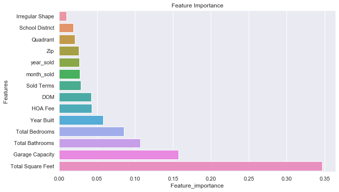

```python
plt.figure(figsize=(10,6))
plt.title('Feature Importance')
sns.barplot(y='Features', x='Feature_importance', data=FIM)
plt.show()
```

## Does more important feature mean more significant?

```python
import statsmodels.api as sm
```

```python
# With statsmodels, we need to mannually add a constant to our dataset!
X_test_wc = sm.add_constant(X_test)
X_train_wc = sm.add_constant(X_train)
```

```python
# Fit the model
model = sm.OLS(y_train,X_train_wc)
statsmodels_reg= model.fit()
```

```python
statsmodels_reg.summary()
```

OLS Regression Results

| Dep. Variable: | Sold Price | R-squared: | 0.755 |
| --- | --- | --- | --- |
| Model: | OLS | Adj. R-squared: | 0.754 |
| Method: | Least Squares | F-statistic: | 630.4 |
| Date: | Mon, 05 Apr 2021 | Prob (F-statistic): | 0.00 |
| Time: | 12:17:34 | Log-Likelihood: | -35655. |
| No. Observations: | 2875 | AIC: | 7.134e+04 |
| Df Residuals: | 2860 | BIC: | 7.143e+04 |
| Df Model: | 14 |  |  |
| Covariance Type: | nonrobust |  |  |

|  | coef | std err | t | P>\|t\| | [0.025 | 0.975] |
| --- | --- | --- | --- | --- | --- | --- |
| const | -4.985e+07 | 2.75e+06 | -18.151 | 0.000 | -5.52e+07 | -4.45e+07 |
| DOM | -55.1928 | 22.736 | -2.428 | 0.015 | -99.773 | -10.612 |
| Garage Capacity | 1.942e+04 | 1286.898 | 15.088 | 0.000 | 1.69e+04 | 2.19e+04 |
| HOA Fee | 1.0187 | 17.429 | 0.058 | 0.953 | -33.156 | 35.194 |
| Irregular Shape | 1.348e+04 | 3881.799 | 3.472 | 0.001 | 5866.477 | 2.11e+04 |
| Quadrant | 5508.5054 | 1044.865 | 5.272 | 0.000 | 3459.741 | 7557.270 |
| School District | -7499.6621 | 2558.191 | -2.932 | 0.003 | -1.25e+04 | -2483.577 |
| Sold Terms | -660.7414 | 977.467 | -0.676 | 0.499 | -2577.353 | 1255.870 |
| Total Bedrooms | 1000.4834 | 1345.759 | 0.743 | 0.457 | -1638.272 | 3639.239 |
| Total Bathrooms | 2022.8305 | 1987.773 | 1.018 | 0.309 | -1874.783 | 5920.444 |
| Total Square Feet | 80.6931 | 1.752 | 46.065 | 0.000 | 77.258 | 84.128 |
| Year Built | 113.5147 | 45.989 | 2.468 | 0.014 | 23.340 | 203.689 |
| Zip | 459.4171 | 268.915 | 1.708 | 0.088 | -67.869 | 986.703 |
| year_sold | 2.459e+04 | 1361.057 | 18.065 | 0.000 | 2.19e+04 | 2.73e+04 |
| month_sold | 2835.0534 | 365.969 | 7.747 | 0.000 | 2117.464 | 3552.643 |

| Omnibus: | 3540.895 | Durbin-Watson: | 1.964 |
| --- | --- | --- | --- |
| Prob(Omnibus): | 0.000 | Jarque-Bera (JB): | 1530235.354 |
| Skew: | 6.092 | Prob(JB): | 0.00 |
| Kurtosis: | 115.364 | Cond. No. | 9.39e+06 |

Warnings:  
[1] Standard Errors assume that the covariance matrix of the errors is correctly specified.  
[2] The condition number is large, 9.39e+06. This might indicate that there are  
strong multicollinearity or other numerical problems.

### Additional links:

1. Decision Trees with sklearn: https://scikit-learn.org/stable/modules/tree.html
2. Ensemble learning with sklearn: https://scikit-learn.org/stable/modules/ensemble.html
3. graphviz: this is used for Tree visualization: http://graphviz.org/
4. Out of Bag errors for random forest: https://scikit-learn.org/stable/auto_examples/ensemble/plot_ensemble_oob.html#sphx-glr-auto-examples-ensemble-plot-ensemble-oob-py